# Session 3 & 4

## Session Outline

1. **How to Write Control Structures**
1. `if-else` statement
2. `ifelse()` function
2. **How to Write Loops**
1. `for` and `while` loops
2. Family of `apply` functions
3. **How to Write a Function**

## How to Write Control Structures

### `if-else` Statement

What is if and else?

– To test a condition and act depending on whether it is TRUE or FALSE

1. if statement

```r
if(condition){
  statement
}
# If condition TRUE,
# then execute the statement
# If FALSE, do nothing
```

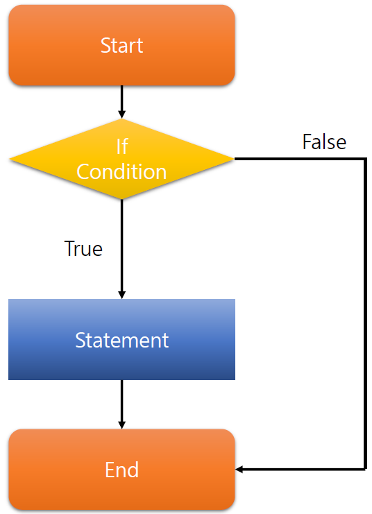

## How to Write Control Structures

### `if-else` Statement

2. if-else statement

```r
if(condition){
  statement1
} else {
  statement2
}
# If condition TRUE,
# then execute statement 1
# If FALSE,
# then execute statement 2
```

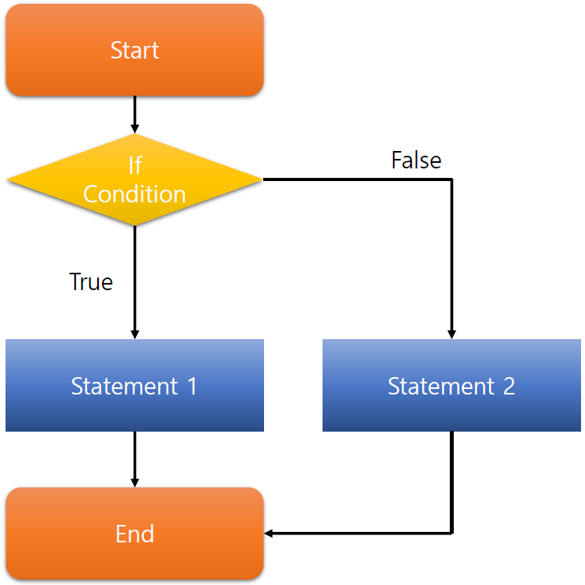

## How to Write Control Structures

### `if-else` Statement

3. else-if statement

```r
if(condition1){
  statement1
} else if(condition2) {
  statement2
} else {
  statement3
}
```

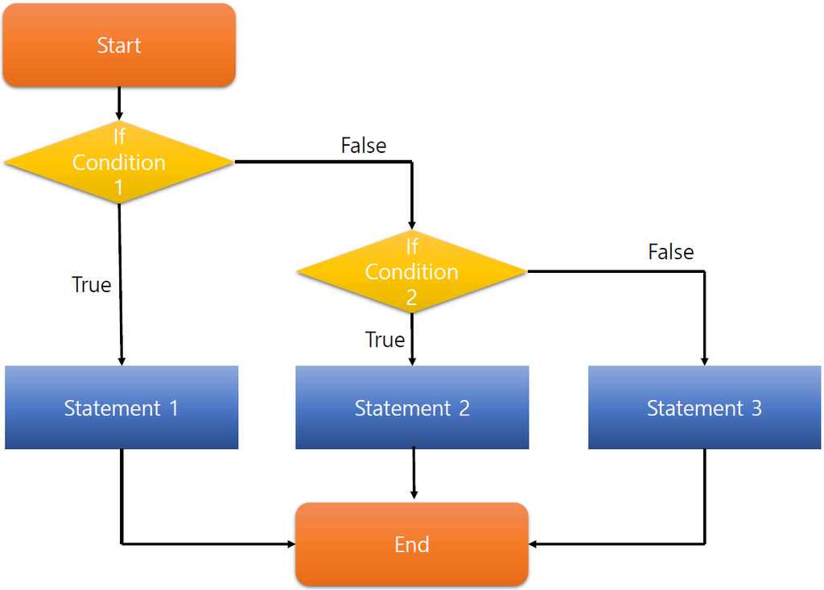

## How to Write Control Structures

### `ifelse()` Function

4. [`ifelse()`](https://www.rdocumentation.org/packages/base/versions/3.6.2/topics/ifelse) function

```r
# Syntax
ifelse(condition, value_for_true, value_for_false)
```

```r
x <- 5
ifelse(x>2, "x is greater than 2", "x is less or equal to 2")
```

```
[1] "x is greater than 2"
```

```r
x <- 1
ifelse(x>2, "x is greater than 2", "x is less or equal to 2")
```

[output not shown]

`ifelse()` function is vectorized

## How to Write Control Structures

### `if-else` Statement

Compare if-else statement and `ifelse()` function

```r
x<-1:5
```

```r
if(x >= 4){
  paste0(x, " is high-rated")
} else if (x >= 2){
  paste0(x, " is mediocre")
} else{
  paste0(x, " is low-rated")
}  # NOT the desired output
```

```r
ifelse(x >= 4, paste0(x, " is high-rated"),
  ifelse(x >= 2, paste0(x, " is mediocre"),
    paste0(x, " is low-rated")
  ) # close the 2nd ifelse function
)   # close the 1st ifelse function

# Vectorized!
```

## How to Write Control Structures

### `Switch` Statement

```r
# Syntax
switch(expression, list_of_values)
```

```r
# Example
switch("b", "a"="alpha", "b"="beta", "zeta")  # match by character
switch(1, "a"="alpha", "b"="beta", "zeta")    # match by index
switch("c", "a"="alpha", "b"="beta", "zeta")  # returns "zeta" if no match
```

## How to Write Loops

### `for` Loops

What is a for loop?

– To repeat a specific statement for a known number of iteration

```r
# Syntax
for(index in vector){
  statement
}
```

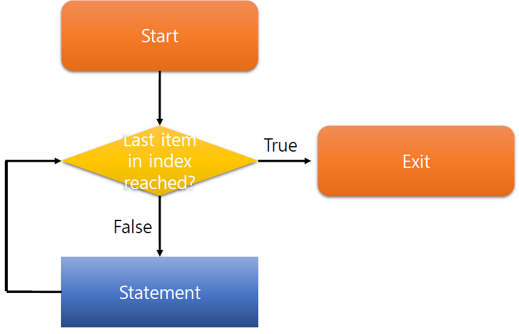

## How to Write Loops

### `for` Loops

```r
# Example: How to count and save using the for loop
# Count the number of leap years between 1900 and 2000
# Save the leap years

count <- 0
leap_years=NULL

for(x in 1900:2000){
  if( (x %% 4 == 0) & ((x %% 100 !=0) | (x %% 400 == 0)) ){
    count = count+1   # R does not have += or ++
    leap_years = c(leap_years, x)
  }
}
count                 # 25
leap_years            # 1904, 1908, 1912, ..., 2000
```

## How to Write Loops

### `for` Loops

Nested for loops

```r
for (i in 1:2){                       # indexing iterations is very common
  for(j in c("apple", "banana"))      # but... can be any vector or list
    print(paste(i, j , collapse=" ")) # without {}. Not recommended
}
```

```
[1] "1 apple"
[1] "1 banana"
[1] "2 apple"
[1] "2 banana"
```

## How to Write Loops

### `for` Loops

break – stop & exit loop

```r
for(i in 1:5){
  if(i == 3) break
  print(i)
}
```

```
[1] 1
[1] 2
```

next – skip to the next iter.

```r
for(i in 1:5){
  if(i == 3) next
  print(i)
}
```

```
[1] 1
[1] 2
[1] 4
[1] 5
```

## How to Write Loops

### `for` Loops

When the length of output is known…

```r
proc.time() -> ptm  # Sys.time() works
x <- NULL
for(i in 1:10^4){
  set.seed(i)       # to replicate
  x = c(x, rnorm(1))# new x after ea. iter.
  # print(i)        # to check progress
}
proc.time() - ptm
```

```
   user  system elapsed
   0.13    0.00    0.12
```

```r
proc.time() -> ptm
y <- numeric(10^4)
for(i in 1:length(y)){
  set.seed(i)
  y[i] = rnorm(1) # fill-in x
  # print(i)
}
proc.time() - ptm
```

```
   user  system elapsed
   0.05    0.00    0.04
```

## How to Write Loops

### `while` Loops

What is a while loop?

– To repeat a specific statement until a condition is FALSE

```r
# Syntax
while(condition){
  statement
}
```

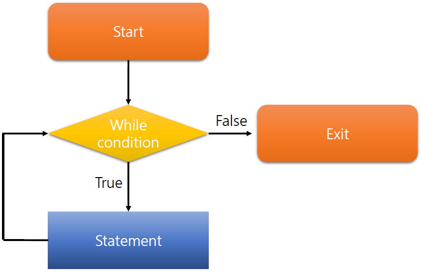

## How to Write Loops

### `while` loops

```r
# Example
count <- 1
while(count < 4){
  print(paste0(count, " mississippi ... "))
  count=count+1
}
print("zzZ")
```

```
[1] "1 mississippi ... "
[1] "2 mississippi ... "
[1] "3 mississippi ... "
```

```
[1] "zzZ"
```

## How to Write a Function

1. What is a function?

– A block of code/instruction that take-in argument(s) and returns its result

2. Why do we write functions?
1. Allow us to reuse code
- Write abstract code! Avoid hard coding
2. Allow us to make a complex code into steps
- Test small part of a larger code and isolate the rest
- Chain functions
3. Keeping the namespace clean
- Recall the difference between `<-` and `<<-` assignments

**NOTE**: Functions are also objects in R!

## How to Write a Function

### Basic Syntax

```r
func_name <- function(arguments){
  body
}
```

```r
f <- function(x){
  x+2
}
# func name: f
# argument: x
# body: x+2
f(2)
```

```
[1] 4
```

```r
f <- function(x){
  return(x+2)
  print("not printed")
}
# Use return function
# o.w. last line
f(2)
```

```
[1] 4
```

```r
f <- function(x){
  x+2
  print("not printed")
}
#
#
f(2)
```

```
[1] "not printed"
```

## How to Write a Function

### Setting Default Arguments

```r
g <- function(x=1, y = 2){ # set default values for x and y
  x+y
}
g()       # 1 + 2
```

```
[1] 3
```

```r
g(x=3)    # 3 + 2
```

```
[1] 5
```

```r
g(5, 10)  # 5 + 10
```

```
[1] 15
```

## How to Write a Function

### Passing Additional Arguments

… (dot-dot-dot)

Additional arguments can be passed out to function(s) embedded in a function

```r
f1 <- function(x, y){
  x+y
}
```

```r
f2 <- function(a, x, y){
  a * f1(x, y)
}

f2(5, 1, 2)
```

```
[1] 15
```

```r
f2 <- function(a, ...){
  a * f1(...)
}
# f2(5, 1, 2)
f2(5, x=1, y=2)
```

```
[1] 15
```

```r
f2 <- function(a, ...){
  a * f1(x=..1, y=..2)
}
# ..N to refer position
f2(5, 1, 2)
```

```
[1] 15
```

## Compose Multiple Functions

- Method1: Save intermediate results
- Method2: Nest function calls
- Method3: Use pipe operators

```r
x <- 1:10
```

Method1

```r
step1 <- sqrt(x)
step2 <- log(step1)
mean(step2)
#Creates new objects
```

```
[1] 0.7552206
```

Method2

```r
mean(log(sqrt(x)))
# Compact but...
# Can stretch out
# Diff. to read
```

```
[1] 0.7552206
```

Method3

```r
x |>
  sqrt() |>
  log() |>
  mean()
```

```
[1] 0.7552206
```

## Pipe Operator

1. [`|>`](https://www.r-bloggers.com/2021/05/the-new-r-pipe/) is R’s base pipe operator
2. `%>%` is a pipe operator from the [`magrittr`](https://cran.r-project.org/web/packages/magrittr/magrittr.pdf) package

Or any packages that uses the `magrittr` package as a dependent package  
e.g. `tidyverse`

```r
# without a pipe
x <- c(1, 10, 100)
log10(x)
```

```
[1] 0 1 2
```

```r
# base pipe |>
x |>
  log10()
```

```
[1] 0 1 2
```

```r
library(magrittr)
x %>%
  log10()
```

```
[1] 0 1 2
```

**NOTE**: The base pipe `|>` is faster, but `%>%` can use placeholder

## Pipe Operator

### `.` as a Placeholder for `%>%`

```r
f(x, y) # "roughly" equivalent to
y %>%
  f(x, .)
```

```r
f<-function(x,y) x^y
1 %>%
  f(2)    # 1^2
```

```
[1] 1
```

```r
# compare the difference
1 %>%
  f(2,.)  # 2^1
```

```
[1] 2
```

```r
1:10 %>%
  {c(avg=mean(.), stdev=sd(.))}
```

```
    avg   stdev
5.50000 3.02765
```

## Error Handling in R

### Motivation …

Example

```r
a_list=list(1, 2, "a", 4)
# Note: a list can have different object types

for(i in a_list){
  print(i+2)
}
# Error Introduced b/c of "a"+2
# the for loop breaks and exits
```

[output not shown]

```
Error in i + 2: non-numeric argument to binary operator
```

## Error Handling in R

### [`tryCatch()`](https://rdrr.io/github/Dans-labs/R-package_EmilMisc/man/tryCatch.html) and [`try()`](https://www.rdocumentation.org/packages/base/versions/3.6.2/topics/try) functions

1. [`try()`](https://www.rdocumentation.org/packages/base/versions/3.6.2/topics/try) – Returns an error object when there is error

Use `try()` function to ignore errors and continue the execution

2. [`tryCatch()`](https://rdrr.io/github/Dans-labs/R-package_EmilMisc/man/tryCatch.html) – Call condition handling function(s)

Use `tryCatch()` function to handle conditions as you want

**NOTE**: Note there are other condition handling method including `withCallingHandlers()` function.

**NOTE**: How to ignore [warnings](https://www.rdocumentation.org/packages/base/versions/3.6.2/topics/warning) and [messages](https://www.rdocumentation.org/packages/base/versions/3.6.2/topics/message)

**NOTE**: Use [`options()`](https://www.rdocumentation.org/packages/base/versions/3.6.2/topics/options) function to supress error meesages

## Error Handling in R

### [`tryCatch()`](https://rdrr.io/github/Dans-labs/R-package_EmilMisc/man/tryCatch.html) – basic syntax

```r
tryCatch({
    statements
  },
  error=function(e){
    error-handling-code
  },
  warning=function(w){
    warning-handling-code
  },
  message=function(m){
    message-handling-code
  },
  finally={
    statements
  })
```

## [`tryCatch()`](https://www.rdocumentation.org/packages/R.oo/versions/1.2.7/topics/trycatch)

### Example

```r
tc <- function(x){
  tryCatch({
    x+2
  },
  error=function(...){
    if(is.character(x))
      paste0(x, " is a character")
  })
}
```

```r
tc(2)
```

```
[1] 4
```

```r
tc("2")
```

```
[1] "2 is a character"
```

```r
tc(NA)
```

```
[1] NA
```

## [`tryCatch()`](https://www.rdocumentation.org/packages/R.oo/versions/1.2.7/topics/trycatch)

### Example – tryCatch in a loop

```r
# Recall previous example
a_list=list(1,2,"a",4)
for(i in a_list){
  print(
    tryCatch(
      {i+2},
      error=function(e){NA}  # If error, return NA
    )
  )
}
```

```
[1] 3
[1] 4
[1] NA
[1] 6
```

## [`tryCatch()`](https://www.rdocumentation.org/packages/R.oo/versions/1.2.7/topics/trycatch)

### Another Example – run at your leisure

```r
tc <- function(x){
  tryCatch({x},
    error=function(e){print("error-handling-code")},
    warning=function(w){print("warning-handling-code")},
    message=function(m){print("message-handling-code")},
    finally = {message("final message")}
)}

# Check how to generate messages when writing a function
good_f <- function(){print("good")}
err_f  <- function(){stop("this is an error")}
warn_f <- function(){warning("this is a warning")}
msg_f  <- function(){message("this is a message")}

tc(good_f()); tc(err_f()); tc(warn_f()); tc(msg_f())
```

## Family of Apply Functions

Apply functions are more efficient than loops  
– use it to avoid explicit uses of loops

1. [`apply()`](https://www.rdocumentation.org/packages/base/versions/3.6.2/topics/apply) function

```r
# Basic Syntax
apply(x, margin, FUN, ...)
# x: a matrix/array (important!)
# margin: 1 <- row, 2 <- column, 1:2 <- each cell
# FUN: a function to apply
# ...: additional arguments for the FUN
```

2. [`lapply()`](https://www.rdocumentation.org/packages/base/versions/3.6.2/topics/lapply)

**NOTE**: There are many variations of apply function. We will cover `apply()`, `lapply()`, and `sapply()`

## `apply` Function

### Example

```r
df<-data.frame(col1=1:4, col2=c(1,2, NA, NA), col3=c(NA, "2", "3", "4"))

# Take the avg. of column 1 & 2
# apply(df[, 1:2], 2, mean)          # NA in 2nd col
apply(df[, 1:2], 2, mean, na.rm=T)
```

```
col1 col2
 2.5  1.5
```

```r
# Count the number of NAs in each column
apply(df, 2, function(x){sum(is.na(x))})
```

```
col1 col2 col3
   0    2    1
```

## `apply` Function

### Example

```r
# Sum each column
# Desired output: 10 3 9
df<-data.frame(
  col1=1:4,
  col2=c(1,2, NA, NA),
  col3=c("N/A", "2", "3", "4"))

# Recall tryCatch
apply(df, 2, function(x){tryCatch({sum(x)}, error=function(e)NA)})
# At least we expect the result to be 10 NA NA
# But why all NA?

apply(df, 2, function(x, ...){sum(as.numeric(x), ...)}, na.rm=T)
# Read the warnings msg. What was the trigger?
```

## `lapply` Function

### Examples

[`lapply()`](https://www.rdocumentation.org/packages/base/versions/3.6.2/topics/lapply) function

`sapply()` function

```r
lapply(x, FUN, ...)  # "list" apply
# x: a vector or a list
# lapply function returns a list

sapply(x, FUN, ...)  # "simple" apply.
# A wrapper for lapply()
# Simplify the output if possible
```

**NOTE**: There are other apply functions – e.g. [`tapply()`](https://www.rdocumentation.org/packages/base/versions/3.6.2/topics/tapply), [`mapply()`](https://www.rdocumentation.org/packages/base/versions/3.6.2/topics/mapply), and a whole lot more…

## `lapply` Function

### Examples

```r
l=list(a=matrix(1:9, nrow=3), b=matrix(7:10, nrow=2), c=matrix(4:15, nrow=4))
```

```r
options(digits = 2)
lapply(l, function(x){
  c(avg=mean(x), std=sd(x))
})
```

```
$a
avg std
5.0 2.7

$b
avg std
8.5 1.3

$c
avg std
9.5 3.6
```

```r
options(digits = 2)
sapply(l, function(x){
  c(avg=mean(x), std=sd(x))
})
```

```
      a   b   c
avg 5.0 8.5 9.5
std 2.7 1.3 3.6
```

## `lapply` Function

### Examples

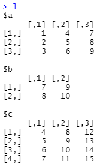

```r
# 1st row
lapply(l, "[", 1, )
```

```
$a
[1] 1 4 7

$b
[1] 7 9

$c
[1]  4  8 12
```

```r
lapply(l, "[", , 2)   # 2nd col
lapply(l, "[", 1, 2)  # 1st row, 2nd column
# "[[" can also be used as an argument
```